# COD_20230604_HOST_5_controls

Minsik Kim

2023-06-04

# Loading packages

```r
#===============================================================================
#BTC.LineZero.Header.1.1.0
#===============================================================================
#R Markdown environment setup and reporting utility.
#===============================================================================
#RLB.Dependencies:
#   knitr, magrittr, pacman, rio, rmarkdown, rmdformats, tibble, yaml
#===============================================================================
#Input for document parameters, libraries, file paths, and options.
#=+=+=+=+=+=+=+=+=+=+=+=+=+=+=+=+=+=+=+=+=+=+=+=+=+=+=+=+=+=+=+=+=+=+=+=+=+=+=+=
knitr::opts_chunk$set(message=FALSE, warning = FALSE)

path_working <- "/Users/minsikkim/Dropbox (Partners HealthCare)/Project_SICAS2_microbiome/5_Scripts/MGK/Host_depletion_git/"
path_library <- "/Library/Frameworks/R.framework/Resources/library"
str_libraries <- c(
    "readxl", "phyloseq", "tidyverse", "pacman", "yaml"
)

path_working <- "/Users/minsikkim/Dropbox (Partners HealthCare)/Project_SICAS2_microbiome/5_Scripts/MGK/Host_depletion_git"
path_library <- "/Library/Frameworks/R.framework/Resources/library"
str_libraries <- c("readxl", "phyloseq", "tidyverse", "pacman", "yaml", "ggplot2", "vegan", "microbiome", "ggtext")

YAML_header <-
'---
title: "COD_20230604_HOST_5_controls"
author: "Minsik Kim"
date: "2032.06.04"
output:
    rmdformats::downcute:
        downcute_theme: "chaos"
        code_folding: hide
        fig_width: 6
        fig_height: 6
---'
seed <- "20230604"

#=-=-=-=-=-=-=-=-=-=-=-=-=-=-=-=-=-=-=-=-=-=-=-=-=-=-=-=-=-=-=-=-=-=-=-=-=-=-=-=
#Loads libraries, file paths, and other document options.
#=-=-=-=-=-=-=-=-=-=-=-=-=-=-=-=-=-=-=-=-=-=-=-=-=-=-=-=-=-=-=-=-=-=-=-=-=-=-=-=
FUN.LineZero.Boot <- function() {
    .libPaths(path_library)

    require(pacman)
    pacman::p_load(c("knitr", "rmarkdown", "rmdformats", "yaml"))

    knitr::opts_knit$set(root.dir = path_working)

    str_libraries |> unique() |> sort() -> str_libraries
    pacman::p_load(char = str_libraries)

    set.seed(seed)
}
FUN.LineZero.Boot()
#=-=-=-=-=-=-=-=-=-=-=-=-=-=-=-=-=-=-=-=-=-=-=-=-=-=-=-=-=-=-=-=-=-=-=-=-=-=-=-=
#Outputs R environment report.
#=-=-=-=-=-=-=-=-=-=-=-=-=-=-=-=-=-=-=-=-=-=-=-=-=-=-=-=-=-=-=-=-=-=-=-=-=-=-=-=
FUN.LineZero.Report <- function() {
    cat("Line Zero Environment:\n\n")
    paste("R:", pacman::p_version(), "\n") |> cat()
    cat("Libraries:\n")
    for (str_libraries in str_libraries) {
        paste(
            "    ", str_libraries, ": ", pacman::p_version(package = str_libraries),
            "\n", sep = ""
        ) |> cat()
    }
    paste("\nOperating System:", pacman::p_detectOS(), "\n") |> cat()
    paste("    Library Path:", path_library, "\n") |> cat()
    paste("    Working Path:", path_working, "\n") |> cat()
    paste("Seed:", seed, "\n\n") |> cat()
    cat("YAML Header:\n")
    cat(YAML_header)
}
FUN.LineZero.Report()
```

```
## Line Zero Environment:
##
## R: 4.2.2
## Libraries:
##     readxl: 1.4.2
##     phyloseq: 1.40.0
##     tidyverse: 2.0.0
##     pacman: 0.5.1
##     yaml: 2.3.7
##     ggplot2: 3.4.1
##     vegan: 2.6.4
##     microbiome: 1.18.0
##     ggtext: 0.1.2
##
## Operating System: Darwin
##     Library Path: /Library/Frameworks/R.framework/Resources/library
##     Working Path: /Users/minsikkim/Dropbox (Partners HealthCare)/Project_SICAS2_microbiome/5_Scripts/MGK/Host_depletion_git
## Seed: 20230604
##
## YAML Header:
## ---
## title: "COD_20230604_HOST_5_controls"
## author: "Minsik Kim"
## date: "2032.06.04"
## output:
##     rmdformats::downcute:
##         downcute_theme: "chaos"
##         code_folding: hide
##         fig_width: 6
##         fig_height: 6
## ---
```

# Loading data

## Analysis prep

### Controls of HOST project

**Sequencing result phyloseq object was loaded**

```r
# Loading files -----------------------------------------------------------
#loading tidy phyloseq object
phyloseq <- readr::read_rds("/Users/minsikkim/Dropbox (Partners HealthCare)/Project_SICAS2_microbiome/4_Data/2_Tidy/Phyloseq/PHY_20221129_MGK_host_tidy_tax.rds")


#sample data loading
sample_data <- sample_data(phyloseq$phyloseq_count)
```

### SICAS2 positive controls

**Mock community data from other project / having different lot number was loaded**

```r
phyloseq_control_sample <- read.csv("/Users/minsikkim/Dropbox (Partners HealthCare)/Project_SICAS2_microbiome/1_Daily_Log/MGK/LOG_20220926_MGK_extraction_data.csv")
phyloseq_control_sample <- subset(phyloseq_control_sample, phyloseq_control_sample$spikein_type != "high" | is.na(phyloseq_control_sample$spikein_type))
#Making metadata
phyloseq_control_sample <- select(phyloseq_control_sample, c("BaylorID", "Type", "extraction_date"))
names(phyloseq_control_sample) <- c("baylor_id", "reagent", "extraction_date")
rownames(phyloseq_control_sample) <- phyloseq_control_sample$biom_id
phyloseq_control_sample$sample_type <- ifelse(phyloseq_control_sample$reagent == "reagent", "Neg.", "Mock")
phyloseq_control_sample$lot_number <- ifelse(phyloseq_control_sample$reagent == "reagent", NA, str_split_fixed(phyloseq_control_sample$reagent, pattern = "_", 4) %>% data.frame %>% .$X4)

phyloseq_control_sample$extraction_date <- as.Date(phyloseq_control_sample$extraction_date, format = c("%m/%d/%y"))
phyloseq_control_sample$lai_id <- paste(phyloseq_control_sample$control, as.Date(phyloseq_control_sample$extraction_date), sep = "_")

#Adding metadata - knead data output
kneaddata_1 <- read.csv("/Users/minsikkim/Dropbox (Partners HealthCare)/Project_Baylor/4_Data/1_Raw/Baylor_Processed/20220628_PQ00254_SICAS2/P1488_PQ00254_Deliverables_With_Spikeins/ReadStats_w_spikeins.tsv", sep = "\t")
kneaddata_2 <- read.csv("/Users/minsikkim/Dropbox (Partners HealthCare)/Project_Baylor/4_Data/1_Raw/Baylor_Processed/20220216_Baylor_SICAS2_Biobakery3_All_Kingdom_Corrected_ID/Deliverables/ReadStats.txt", sep = "\t")
kneaddata_1 <- kneaddata_1 %>% select(c(names(kneaddata_2)))

kneaddata_sicas <- rbind(kneaddata_1, kneaddata_2) %>% rename(baylor_id = "SampleID")
phyloseq_control_sample <- merge(kneaddata_sicas, phyloseq_control_sample, by = "baylor_id")

seq_data <- biomformat::read_biom("/Users/minsikkim/Dropbox (Partners HealthCare)/Project_Baylor/4_Data/1_Raw/Baylor_Processed/20220216_Baylor_SICAS2_Biobakery3_All_Kingdom_Corrected_ID/Deliverables/metaphlan3/metaphlan3.allkingdoms.EstCount.biom")
seq_data2 <- biomformat::read_biom("/Users/minsikkim/Dropbox (Partners HealthCare)/Project_Baylor/4_Data/1_Raw/Baylor_Processed/20220628_PQ00254_SICAS2/P1488_PQ00254_Deliverables_With_Spikeins/metaphlan3/metaphlan3.allkingdoms.EstCount.biom")


seq_data <- import_biom(seq_data)
seq_data2 <- import_biom(seq_data2)
sample_names(seq_data) <- str_split_fixed(sample_names(seq_data), "-", 2) %>% data.frame() %>% .[,1]
row.names(phyloseq_control_sample) <- phyloseq_control_sample$baylor_id
ctrl_data <- merge_phyloseq(seq_data, sample_data(phyloseq_control_sample))
ctrl_data2 <- merge_phyloseq(seq_data2, sample_data(phyloseq_control_sample))
phyloseq$sicas2_control <- merge_phyloseq(ctrl_data2, ctrl_data)



colnames(tax_table(phyloseq$sicas2_control)) <- c("Domain", "Phylum", "Class", "Order", "Family",  "Genus", "Species")

sample_data(phyloseq$phyloseq_count)$lot_number <- ifelse(sample_data(phyloseq$phyloseq_count)$sample_type == "Mock",
                                                          ifelse(sample_data(phyloseq$phyloseq_count)$extraction_date < "20221212",
                                                          190633,
                                                          213683),
                                                          NA)
phyloseq$positives <- merge_phyloseq(phyloseq$phyloseq_count, phyloseq$sicas2_control) %>% subset_samples(sample_type == "Mock")
```

### Alpha diversity indices

**Alpha diversity indices were calculated and added to the metadata**

- to eliminate samples with zero OTUs

```r
alpha_diversity <- function(data) {
        otu_table <- otu_table(data) %>% .[colSums(.) !=0]
        S.obs <- rowSums(t(otu_table) != 0)
        sample_data <- sample_data(data)
        data_evenness <- vegan::diversity(t(otu_table)) / log(vegan::specnumber(t(otu_table))) # calculate evenness index using vegan package
        data_shannon <- vegan::diversity(t(otu_table), index = "shannon") # calculate Shannon index using vegan package
        data_hill <- exp(data_shannon)                           # calculate Hills index
        data_dominance <- microbiome::dominance(otu_table, index = "all", rank = 1, aggregate = TRUE) # dominance (Berger-Parker index), etc.
        data_invsimpson <- vegan::diversity(t(otu_table), index = "invsimpson")                          # calculate Shannon index using vegan package
        alpha_diversity <- cbind(S.obs, data_shannon, data_hill, data_invsimpson, data_evenness,data_dominance) # combine all indices in one data table
        sample_data <- merge(data.frame(sample_data), alpha_diversity, by = 0, all = T) %>% column_to_rownames(var = "Row.names")
}
phyloseq_unfiltered <- phyloseq
sample_data(phyloseq_unfiltered$phyloseq_rel) <- sample_data(alpha_diversity(phyloseq$phyloseq_count))
sample_data(phyloseq_unfiltered$phyloseq_count) <- sample_data(alpha_diversity(phyloseq$phyloseq_count))
sample_data(phyloseq_unfiltered$phyloseq_path_rpkm) <- sample_data(alpha_diversity(phyloseq$phyloseq_path_rpkm))
sample_data(phyloseq_unfiltered$positives) <- sample_data(alpha_diversity(phyloseq$positives))
phyloseq_control_rel <- subset_samples(phyloseq_unfiltered$phyloseq_rel, sample_type == "Mock" | sample_type == "Neg.") #adding data of controls
phyloseq_mock_rel <- transform_sample_counts(phyloseq_unfiltered$positives, function(x) {x/sum(x)})
```

# Exploratory analysis

### Bar plot of controls (Positive)

**Some possible contaminants were identified in extraction controls**

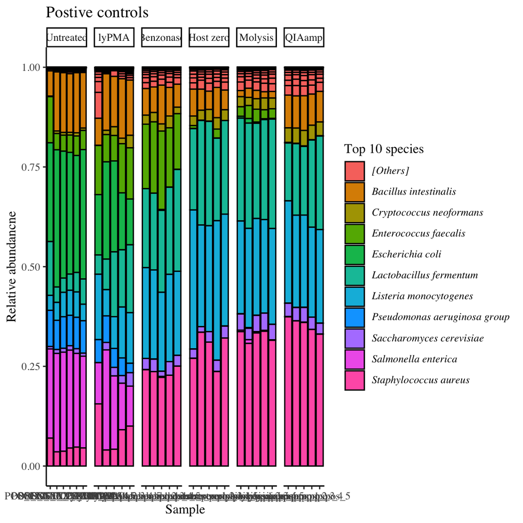

```r
#Manipulating phyloseq - only top 10

phyloseq_control_rel %>%
        subset_samples(., sample_type == "Mock") %>%
        tax_table() %>%
        cbind(species20 = "[Others]") %>%
        {top20species <- head(taxa_sums(subset_samples(phyloseq_control_rel,sample_type == "Mock" & S.obs != 0)) %>%
                                data.frame %>%
                                arrange(-.) %>%
                                row.names(), 10)
   .[top20species, "species20"] <- as.character(.[top20species, "Species"])
   .[, 9] <- .[, 9] %>% gsub("s__", "", .) %>% gsub("_", " ", .) %>% paste("<i>", ., "</i>", sep = "")
   phyloseq_temp <- subset_samples(phyloseq_control_rel,sample_type == "Mock" & S.obs != 0)
   tax_table(phyloseq_temp) <- tax_table(.)
   phyloseq_temp
  } %>%
        plot_bar(., fill="species20") +
        ylab("Relative abundancne") +
        theme_classic(base_size = 11, base_family = "serif") +
        ggtitle("Postive controls") +
        theme(legend.text = element_markdown()) +
        guides(fill=guide_legend(title="Top 10 species")) +
        facet_wrap (~ factor(treatment, levels = c("Untreated", "lyPMA", "Benzonase", "Host zero", "Molysis", "QIAamp")),
                    scales= "free_x", nrow=1)
```

```r
#there could be opportunistic pathogens...
```

### Positives of other projects

**Mock community controls of other projects from other sequencing batches / different lot numbers**

Lot# 213683 & 190633 were used for the host depletion study.

The top 10 species are aligning with expected taxa in the mock community besides *Bacillus intestinallis*.

**It seems like Metaphlan failed to assign taxa precisely.**

Expected taxa in Zymo D6300 are

“Pseudomonas_aeruginosa”, “Escherichia_coli”, “Salmonella_enterica”, “Lactobacillus_fermentum”, “Enterococcus_faecalis”, “Staphylococcus_aureus”, “Listeria_monocytogenes”, **“Bacillus_subtilis”,** “Saccharomyces_cerevisiae”, “Cryptococcus_neoformans”

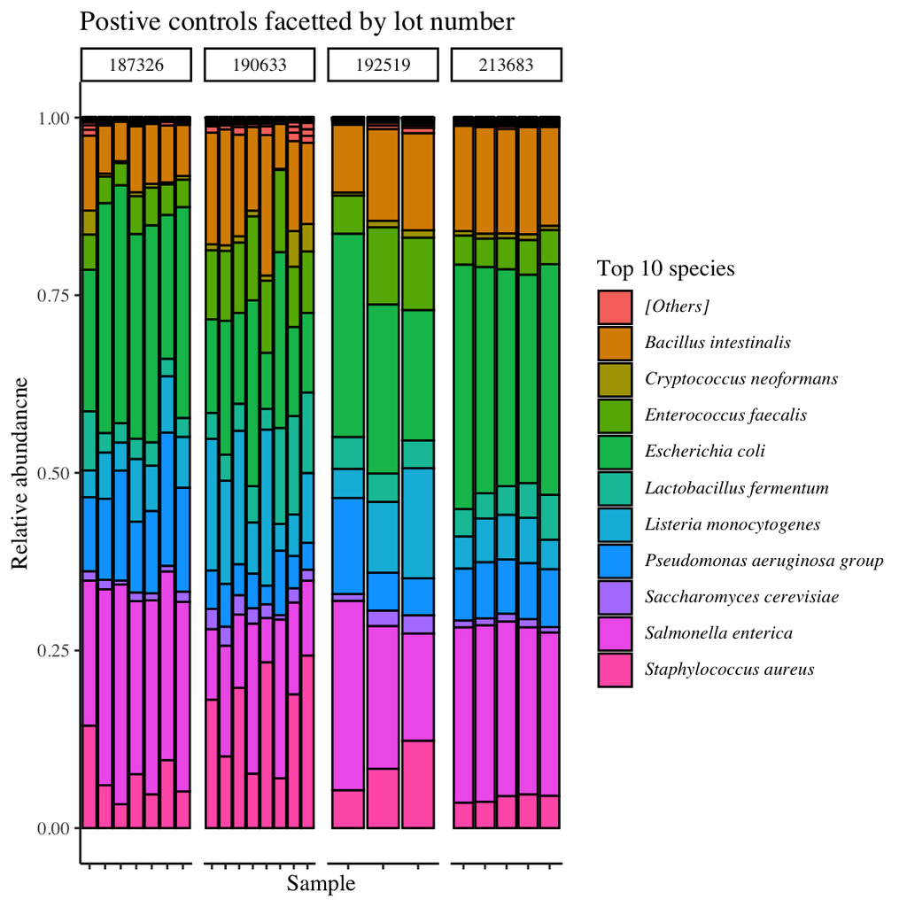

```r
#Manipulating phyloseq - only top 10


phyloseq_mock_rel_untreated <- phyloseq_mock_rel %>%
        subset_samples(treated == 0 | is.na(treated))

phyloseq_mock_rel_untreated %>%
        tax_table() %>%
        cbind(species20 = "[Others]") %>%
        {top20species <- head(taxa_sums(subset_samples(phyloseq_mock_rel_untreated,sample_type == "Mock" & S.obs != 0)) %>%
                                data.frame %>%
                                arrange(-.) %>%
                                row.names(), 10)
   .[top20species, "species20"] <- as.character(.[top20species, "Species"])
   .[, 9] <- .[, 9] %>% gsub("s__", "", .) %>% gsub("_", " ", .) %>% paste("<i>", ., "</i>", sep = "")
   phyloseq_temp <- subset_samples(phyloseq_mock_rel_untreated,sample_type == "Mock" & S.obs != 0)
   tax_table(phyloseq_temp) <- tax_table(.)
   phyloseq_temp
  } %>%
        plot_bar(., fill="species20") +
        ylab("Relative abundancne") +
        theme_classic(base_size = 11, base_family = "serif") +
        ggtitle("Postive controls facetted by lot number") +
        theme(legend.text = element_markdown(), axis.text.x = element_blank()) +
        guides(fill=guide_legend(title="Top 10 species")) +
        facet_wrap(~lot_number, scales = "free_x", ncol = 4)
```

### {-}

## Focusing on unexpected taxa

### Unexpected species in mock community controls

**(after removing expected taxa)**

**Significant contaminants were identified - in one sample**

**Others had some unexpected, evenly distributed taxa**

**This could be 1) background contamination or 2) cross-contamination from kingfisher 3) sequencing artifacts.**

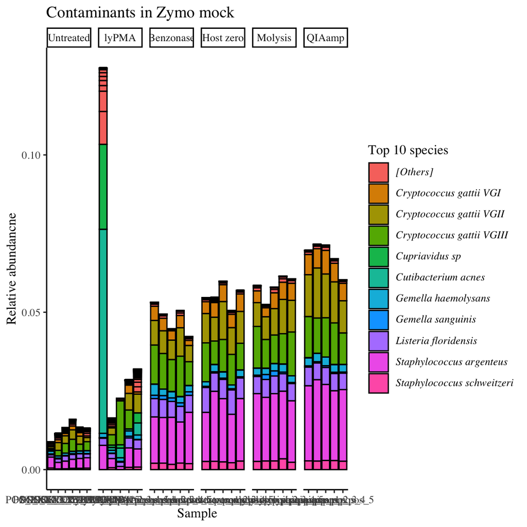

```r
#Manipulating phyloseq - only top 10





phyloseq_control_rel_contam <- subset_taxa(phyloseq_control_rel , !(taxa_names(phyloseq_control_rel) %in% c("Pseudomonas_aeruginosa_group",
                                              "Escherichia_coli",
                                              "Salmonella_enterica",
                                              "Lactobacillus_fermentum",
                                              "Enterococcus_faecalis",
                                              "Staphylococcus_aureus",
                                              "Listeria_monocytogenes",
                                              "Bacillus_intestinalis",
                                              "Saccharomyces_cerevisiae",
                                              "Cryptococcus_neoformans")
                                              )
                                          )

phyloseq_control_rel_contam <- subset_taxa(phyloseq_control_rel_contam, taxa_sums(phyloseq_control_rel_contam) != 0)
phyloseq_control_rel_contam <- subset_samples(phyloseq_control_rel_contam, sample_type != "Neg." & S.obs != 0)


tax_table(phyloseq_control_rel_contam) %>%
        cbind(species20 = "[Others]") %>%
        {top20species <- head(taxa_sums(phyloseq_control_rel_contam) %>%
                                data.frame %>%
                                arrange(-.) %>%
                                row.names(), 10)
   .[top20species, "species20"] <- as.character(.[top20species, "Species"])
   .[, 9] <- .[, 9] %>% gsub("s__", "", .) %>% gsub("_", " ", .) %>% paste("<i>", ., "</i>", sep = "")
   phyloseq_temp <- phyloseq_control_rel_contam
   tax_table(phyloseq_temp) <- tax_table(.)
   phyloseq_temp
  } %>%
        plot_bar(., fill="species20") +
        ylab("Relative abundancne") +
        theme_classic(base_size = 11, base_family = "serif") +
        ggtitle("Contaminants in Zymo mock") +
        theme(legend.text = element_markdown()) +
        guides(fill=guide_legend(title="Top 10 species")) +
        facet_wrap (~ factor(treatment, levels = c("Untreated", "lyPMA", "Benzonase", "Host zero", "Molysis", "QIAamp")),
                    scales= "free_x", nrow=1)
```

### Unexpected taxa from other projects

**Unexpected taxa are quite similar, even from different sequencing batches and different lot# of Zymo D6300**

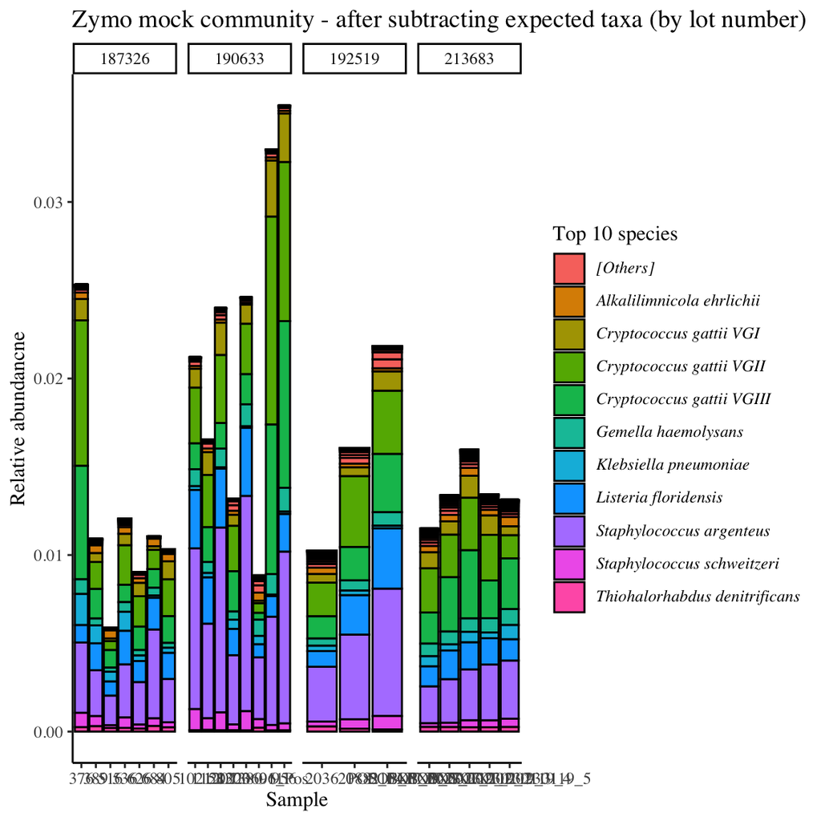

```r
#Manipulating phyloseq - only top 10



phyloseq_mock_rel_untreated_contam <- subset_taxa(phyloseq_mock_rel_untreated , !(taxa_names(phyloseq_mock_rel_untreated) %in% c("Pseudomonas_aeruginosa_group",
                                              "Escherichia_coli",
                                              "Salmonella_enterica",
                                              "Lactobacillus_fermentum",
                                              "Enterococcus_faecalis",
                                              "Staphylococcus_aureus",
                                              "Listeria_monocytogenes",
                                              "Bacillus_intestinalis",
                                              "Saccharomyces_cerevisiae",
                                              "Cryptococcus_neoformans")
                                              )
                                          )

phyloseq_mock_rel_untreated_contam <- subset_taxa(phyloseq_mock_rel_untreated_contam, taxa_sums(phyloseq_mock_rel_untreated_contam) != 0)
phyloseq_mock_rel_untreated_contam <- subset_samples(phyloseq_mock_rel_untreated_contam, sample_type != "Neg." & S.obs != 0)


tax_table(phyloseq_mock_rel_untreated_contam) %>%
        cbind(species20 = "[Others]") %>%
        {top20species <- head(taxa_sums(phyloseq_mock_rel_untreated_contam) %>%
                                data.frame %>%
                                arrange(-.) %>%
                                row.names(), 10)
   .[top20species, "species20"] <- as.character(.[top20species, "Species"])
   .[, 9] <- .[, 9] %>% gsub("s__", "", .) %>% gsub("_", " ", .) %>% paste("<i>", ., "</i>", sep = "")
   phyloseq_temp <- phyloseq_mock_rel_untreated_contam
   tax_table(phyloseq_temp) <- tax_table(.)
   phyloseq_temp
  } %>%
        plot_bar(., fill="species20") +
        ylab("Relative abundancne") +
        theme_classic(base_size = 11, base_family = "serif") +
        ggtitle("Zymo mock community - after subtracting expected taxa (by lot number)") +
        theme(legend.text = element_markdown()) +
        guides(fill=guide_legend(title="Top 10 species")) +
        facet_wrap (~lot_number,scales= "free_x", nrow=1)
```

### {-}

## Genus level analysis

**As some unexpected taxa are from the same genus of expected taxa, the same analysis was conducted at genus level**

### Genus level - whole taxa

**Bar plot at genus level showed top 10 genus are expected taxa**

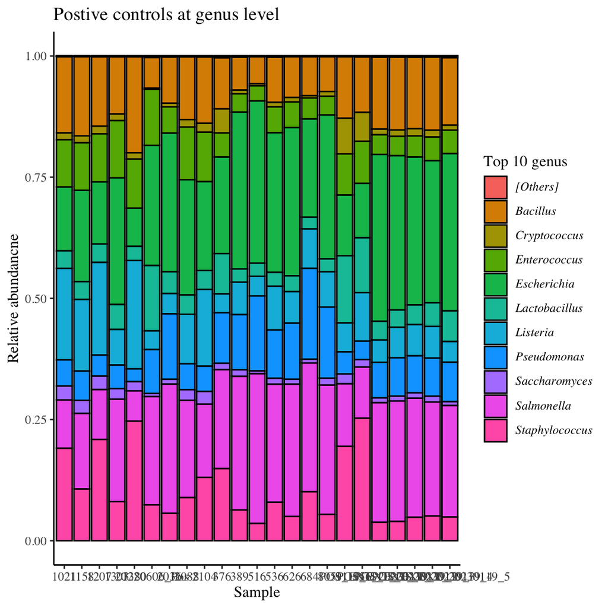

```r
phyloseq_mock_genus <- tax_glom(phyloseq_mock_rel_untreated, taxrank="Genus")

#Manipulating phyloseq - only top 10
phyloseq_mock_genus %>%
        tax_table() %>%
        cbind(species20 = "[Others]") %>%
        {top20species <- head(taxa_sums(subset_samples(phyloseq_mock_genus,sample_type == "Mock" & S.obs != 0)) %>%
                                data.frame %>%
                                arrange(-.) %>%
                                row.names(), 10)
   .[top20species, "species20"] <- as.character(.[top20species, "Genus"])
   .[, 9] <- .[, 9] %>% gsub("g__", "", .) %>% gsub("_", " ", .) %>% paste("<i>", ., "</i>", sep = "")
   phyloseq_temp <- subset_samples(phyloseq_mock_genus,sample_type == "Mock" & S.obs != 0)
   tax_table(phyloseq_temp) <- tax_table(.)
   phyloseq_temp
  } %>%
        plot_bar(., fill="species20") +
        ylab("Relative abundancne") +
        theme_classic(base_size = 11, base_family = "serif") +
        ggtitle("Postive controls at genus level") +
        theme(legend.text = element_markdown()) +
        guides(fill=guide_legend(title="Top 10 genus"))
```

```r
#there could be opportunistic pathogens...
```

### Unexpected genus (after removing expected taxa)

**1. Unexpected genus was 1/10 of unexpected taxa**

**90% of unexpected species seem to be misclassified species**

**other 10% could be contaminants, but again they are quite similar across all the sequencing batch/lot#.**

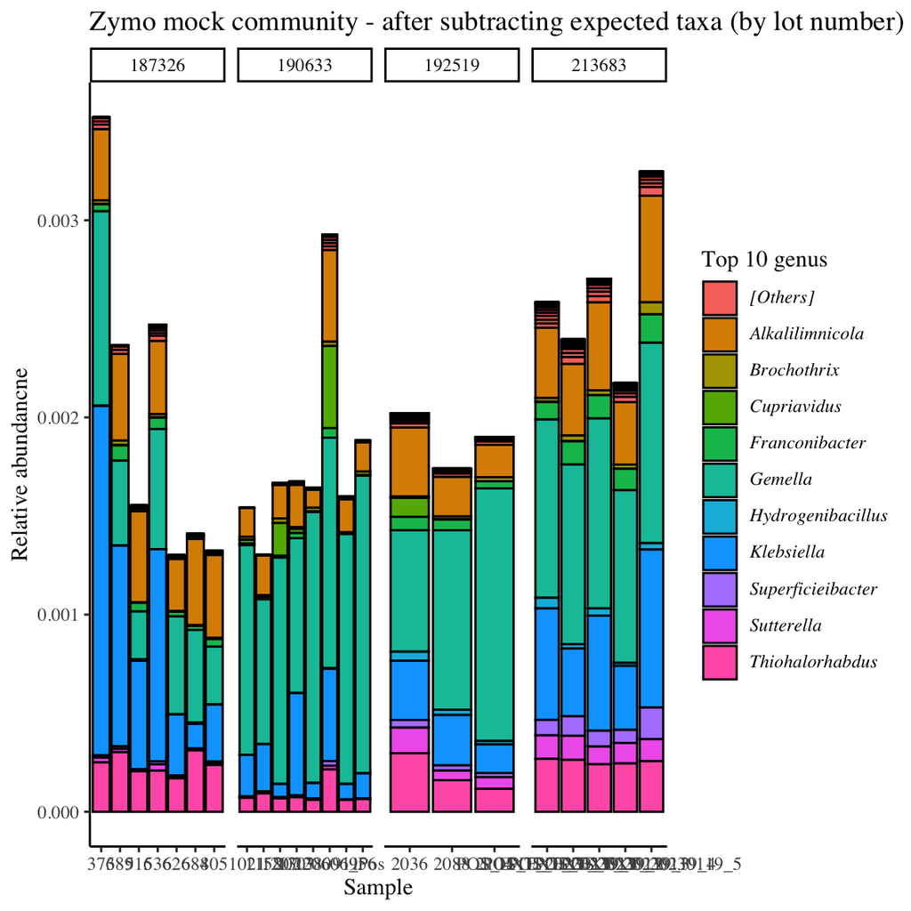

```r
phyloseq_mock_genus_contam <- subset_taxa(phyloseq_mock_genus , !(taxa_names(phyloseq_mock_genus) %in% c("Pseudomonas_aeruginosa_group",
                                              "Escherichia_coli",
                                              "Salmonella_enterica",
                                              "Lactobacillus_fermentum",
                                              "Enterococcus_faecalis",
                                              "Staphylococcus_aureus",
                                              "Listeria_monocytogenes",
                                              "Bacillus_intestinalis",
                                              "Saccharomyces_cerevisiae",
                                              "Cryptococcus_neoformans")
                                              )
                                          )

phyloseq_mock_genus_contam <- subset_taxa(phyloseq_mock_genus_contam, taxa_sums(phyloseq_mock_genus_contam) != 0)
phyloseq_mock_genus_contam <- subset_samples(phyloseq_mock_genus_contam, sample_type != "Neg." & S.obs != 0)

tax_table(phyloseq_mock_genus_contam) %>%
        cbind(species20 = "[Others]") %>%
        {top20species <- head(taxa_sums(phyloseq_mock_genus_contam) %>%
                                data.frame %>%
                                arrange(-.) %>%
                                row.names(), 10)
   .[top20species, "species20"] <- as.character(.[top20species, "Genus"])
   .[, 9] <- .[, 9] %>% gsub("g__", "", .) %>% gsub("_", " ", .) %>% paste("<i>", ., "</i>", sep = "")
   phyloseq_temp <- phyloseq_mock_genus_contam
   tax_table(phyloseq_temp) <- tax_table(.)
   phyloseq_temp
  } %>%
        plot_bar(., fill="species20") +
        ylab("Relative abundancne") +
        theme_classic(base_size = 11, base_family = "serif") +
        ggtitle("Zymo mock community - after subtracting expected taxa (by lot number)") +
        theme(legend.text = element_markdown()) +
        guides(fill=guide_legend(title="Top 10 genus")) +
        facet_wrap (~lot_number,scales= "free_x", nrow=1)
```

### {-}

# Results

**1. Some unexpected taxa were identified**

**2. MetaPhlAn clearly misclassified Bacillus subtilis**

**3. There was clear contamination in one sample (lyPMA treated)**

**4. 90% of unexpected were from the same genus of the expected group**

- i.e., unexpected taxa were 3% in relative abundance at the species level but decreased to 0.3% when the data were aggregated to the genus level.
- These taxa were present regardless of *sequencing batch* or *mock community reagent lot#*

**Therefore, it seems most of the unexpected taxa in the mock community are sequencing artifacts**

**Further analysis (using another pipeline) is ongoing**

**Temporarily, genus level analysis can be conducted**

# Bibliography

```r
#===============================================================================
#BTC.LineZero.Footer.1.1.0
#===============================================================================
#R markdown citation generator.
#===============================================================================
#RLB.Dependencies:
#   magrittr, pacman, stringr
#=-=-=-=-=-=-=-=-=-=-=-=-=-=-=-=-=-=-=-=-=-=-=-=-=-=-=-=-=-=-=-=-=-=-=-=-=-=-=-=
#BTC.Dependencies:
#   LineZero.Header
#===============================================================================
#Generates citations for each explicitly loaded library.
#=-=-=-=-=-=-=-=-=-=-=-=-=-=-=-=-=-=-=-=-=-=-=-=-=-=-=-=-=-=-=-=-=-=-=-=-=-=-=-=
str_libraries <- c("r", str_libraries)
for (str_libraries in str_libraries) {
    str_libraries |>
        pacman::p_citation() |>
        print(bibtex = FALSE) |>
        capture.output() %>%
        .[-1:-3] %>% .[. != ""] |>
        stringr::str_squish() |>
        stringr::str_replace("_", "") |>
        cat()
    cat("\n")
}
```

```
## R Core Team (2022). R: A language and environment for statistical computing. R Foundation for Statistical Computing, Vienna, Austria. URL https://www.R-project.org/. We have invested a lot of time and effort in creating R, please cite it when using it for data analysis. See also 'citation("pkgnam…
## Wickham H, Bryan J (2023). readxl: Read Excel Files_. R package version 1.4.2, <https://CRAN.R-project.org/package=readxl>.
## phyloseq: An R package for reproducible interactive analysis and graphics of microbiome census data. Paul J. McMurdie and Susan Holmes (2013) PLoS ONE 8(4):e61217.
## Wickham H, Averick M, Bryan J, Chang W, McGowan LD, François R, Grolemund G, Hayes A, Henry L, Hester J, Kuhn M, Pedersen TL, Miller E, Bache SM, Müller K, Ooms J, Robinson D, Seidel DP, Spinu V, Takahashi K, Vaughan D, Wilke C, Woo K, Yutani H (2019). "Welcome to the tidyverse." Journal of Open …
## Rinker, T. W. & Kurkiewicz, D. (2017). pacman: Package Management for R. version 0.5.0. Buffalo, New York. http://github.com/trinker/pacman
## Garbett SP, Stephens J, Simonov K, Xie Y, Dong Z, Wickham H, Horner J, reikoch, Beasley W, O'Connor B, Warnes GR, Quinn M, Kamvar ZN (2023). yaml: Methods to Convert R Data to YAML and Back_. R package version 2.3.7, <https://CRAN.R-project.org/package=yaml>. ATTENTION: This citation information …
## H. Wickham. ggplot2: Elegant Graphics for Data Analysis. Springer-Verlag New York, 2016.
## Oksanen J, Simpson G, Blanchet F, Kindt R, Legendre P, Minchin P, O'Hara R, Solymos P, Stevens M, Szoecs E, Wagner H, Barbour M, Bedward M, Bolker B, Borcard D, Carvalho G, Chirico M, De Caceres M, Durand S, Evangelista H, FitzJohn R, Friendly M, Furneaux B, Hannigan G, Hill M, Lahti L, McGlinn D…
## Leo Lahti et al. microbiome R package. URL: http://microbiome.github.io
## Wilke C, Wiernik B (2022). ggtext: Improved Text Rendering Support for 'ggplot2'. R package version 0.1.2, <https://CRAN.R-project.org/package=ggtext>.
```

```r
#===============================================================================
```